# 广州二手房市场数据分析

[链家](https://www.lianjia.com/)是一家集房产交易服务、资产管理服务为一体以数据驱动的价值链房产服务平台，公司业务覆盖租房、新房、二手房、资产管理、海外房产、互联网平台、金融、理财、后房产市场等领域。链家目前已覆盖北京、上海、广州、深圳、天津、成都、青岛、重庆、大连、合肥等28个地区，全国门店数量约8000家，旗下经纪人超过13万名。

[figure not shown]

## 一、数据来源

本文运用R语言来分析探究广州影响二手房市场房价的因素以及预测二手房的价格。借助于爬虫工具我们爬取了链家网广州地区的二手房交易信息。

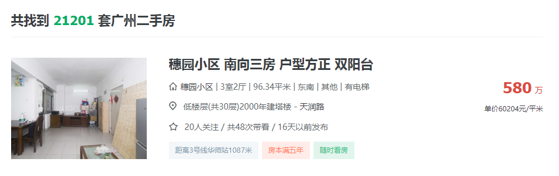

所需要抓取下来的数据就是图片中的的内容，共爬取了广州11个区，每个区爬取再汇总，总共大约18000行（截止**2018/06/11**）。包括广州各个区每套二手房的小区名称、户型、面积、所属区域、楼层、朝向、售价及单价等。

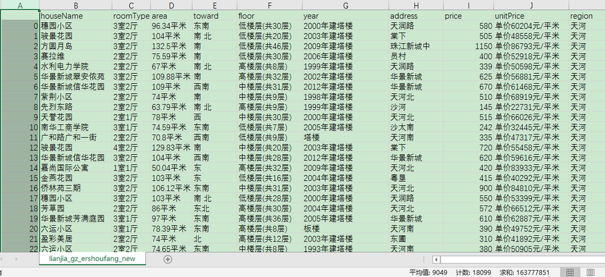

### 数据说明

链家网采集字段详细说明：

| 采集字段 | 字段含义 |
| --- | --- |
| houseName | 房源小区名字 |
| roomType | 房屋户型 |
| area | 房屋面积 |
| toward | 房屋朝向 |
| floor | 房屋楼层 |
| year | 房屋建造时间 |
| address | 房屋地址 |
| price | 房屋价格 |
| unitPrice | 房屋单价 |
| region | 房屋所属区域 |

## 二、数据清洗

这块的工作主要是对数据做一个探索性分析，将不符合要求的记录数据补齐或是剔除，对符合要求的记录进行格式转换、数据切分和重新整合。

```r
# 解决中文乱码
Sys.setlocale("LC_CTYPE", "chs")
```

```
## [1] "Chinese (Simplified)_People's Republic of China.936"
```

```r
rm(list=ls())

# 导入包
library(ggplot2)
library(stringr)
library(RColorBrewer)
library(ggrepel)

data <- read.csv('mywork/data/lianjia_gz_ershoufang_new.csv', header = T)
head(data)
```

|  | X | houseName | roomType | area | toward | floor | year | address | price | unitPrice | region |
| --- | --- | --- | --- | --- | --- | --- | --- | --- | --- | --- | --- |
| 1 | 0 | 穗园小区 | 3室2厅 | 96.34平米 | 东南 | 低楼层(共30层) | 2000年建塔楼 | 天润路 | 580 | 单价60204元/平米 | 天河 |
| 2 | 1 | 骏景花园 | 3室2厅 | 104平米 | 南 北 | 低楼层(共20层) | 2003年建塔楼 | 棠下 | 505 | 单价48558元/平米 | 天河 |
| 3 | 2 | 方圆月岛 | 3室2厅 | 132.5平米 | 南 | 低楼层(共46层) | 2009年建塔楼 | 珠江新城中 | 1150 | 单价86793元/平米 | 天河 |
| 4 | 3 | 赛拉维 | 2室2厅 | 75.59平米 | 南 | 低楼层(共30层) | 2006年建塔楼 | 员村 | 400 | 单价52918元/平米 | 天河 |
| 5 | 4 | 水利电力学院 | 2室2厅 | 67平米 | 南 北 | 高楼层(共8层) | 1999年建塔楼 | 天润路 | 339 | 单价50598元/平米 | 天河 |
| 6 | 5 | 华景新城翠安侬苑 | 3室2厅 | 109.88平米 | 南 | 高楼层(共32层) | 2002年建塔楼 | 华景新城 | 625 | 单价56881元/平米 | 天河 |

```r
# 查看数据类型
str(data)
```

```
## 'data.frame':    18099 obs. of  11 variables:
##  $ X        : int  0 1 2 3 4 5 6 7 8 9 ...
##  $ houseName: Factor w/ 3589 levels "105国道大石段 ",..: 2565 1784 584 2376 2500 1218 1234 3570 2847 2676 ...
##  $ roomType : Factor w/ 42 levels "10室2厅","10室3厅",..: 13 13 13 9 9 13 13 9 9 8 ...
##  $ area     : Factor w/ 5848 levels "0室0厅","10.97平米",..: 5624 224 1171 4188 3699 441 449 4145 3451 4441 ...
##  $ toward   : Factor w/ 167 levels "103.63平米","103平米",..: 161 163 162 162 163 162 166 162 163 164 ...
##  $ floor    : Factor w/ 159 levels "19层","1层","2层",..: 32 21 48 32 108 84 135 159 109 134 ...
##  $ year     : Factor w/ 104 levels "","1970年建板楼",..: 49 58 79 67 46 55 88 44 46 49 ...
##  $ address  : Factor w/ 148 levels "白云大道北","白云大道南",..: 117 111 148 138 117 49 49 114 98 114 ...
##  $ price    : num  580 505 1150 400 339 625 670 510 145 515 ...
##  $ unitPrice: Factor w/ 11083 levels "单价100000元/平米",..: 9717 8093 10914 8811 8459 9327 9850 10364 1298 10201 ...
##  $ region   : Factor w/ 11 levels "白云","从化",..: 9 9 9 9 9 9 9 9 9 9 ...
```

```r
# 删除第一列
data <- data[, -1]

# 提取并转换数据格式
data$area <- as.numeric(sub(pattern = "平米", replacement = "", data$area))
data$floor <- ifelse(substring(data$floor, 1, 3) %in% c('低楼层', '中楼层', '高楼层'), substring(data$floor, 1, 3), '其他')
data$unitPrice <- as.numeric(sub(pattern = "单价(.*)元/平米", replacement = "\\1", data$unitPrice))
data$year <- ifelse(as.numeric(substring(data$year, 1, 4)) %in% c(1950:2100), substring(data$year, 1, 4), '其他')
data$floor <- as.factor(data$floor)
data$year <- as.factor(data$year)

# 删除NA行
data <- na.omit(data)

# 数据清洗后结果
head(data)
```

|  | houseName | roomType | area | toward | floor | year | address | price | unitPrice | region |
| --- | --- | --- | --- | --- | --- | --- | --- | --- | --- | --- |
| 1 | 穗园小区 | 3室2厅 | 96.34 | 东南 | 低楼层 | 2000 | 天润路 | 580 | 60204 | 天河 |
| 2 | 骏景花园 | 3室2厅 | 104.00 | 南 北 | 低楼层 | 2003 | 棠下 | 505 | 48558 | 天河 |
| 3 | 方圆月岛 | 3室2厅 | 132.50 | 南 | 低楼层 | 2009 | 珠江新城中 | 1150 | 86793 | 天河 |
| 4 | 赛拉维 | 2室2厅 | 75.59 | 南 | 低楼层 | 2006 | 员村 | 400 | 52918 | 天河 |
| 5 | 水利电力学院 | 2室2厅 | 67.00 | 南 北 | 高楼层 | 1999 | 天润路 | 339 | 50598 | 天河 |
| 6 | 华景新城翠安侬苑 | 3室2厅 | 109.88 | 南 | 高楼层 | 2002 | 华景新城 | 625 | 56881 | 天河 |

```r
# 查看数据清洗后数据类型
str(data)
```

```
## 'data.frame':    17916 obs. of  10 variables:
##  $ houseName: Factor w/ 3589 levels "105国道大石段 ",..: 2565 1784 584 2376 2500 1218 1234 3570 2847 2676 ...
##  $ roomType : Factor w/ 42 levels "10室2厅","10室3厅",..: 13 13 13 9 9 13 13 9 9 8 ...
##  $ area     : num  96.3 104 132.5 75.6 67 ...
##  $ toward   : Factor w/ 167 levels "103.63平米","103平米",..: 161 163 162 162 163 162 166 162 163 164 ...
##  $ floor    : Factor w/ 4 levels "低楼层","高楼层",..: 1 1 1 1 2 2 4 4 2 4 ...
##  $ year     : Factor w/ 41 levels "1970","1976",..: 23 26 32 29 22 25 35 21 22 23 ...
##  $ address  : Factor w/ 148 levels "白云大道北","白云大道南",..: 117 111 148 138 117 49 49 114 98 114 ...
##  $ price    : num  580 505 1150 400 339 625 670 510 145 515 ...
##  $ unitPrice: num  60204 48558 86793 52918 50598 ...
##  $ region   : Factor w/ 11 levels "白云","从化",..: 9 9 9 9 9 9 9 9 9 9 ...
##  - attr(*, "na.action")=Class 'omit'  Named int [1:183] 3135 3277 3331 3406 3431 3671 3750 3836 3855 3988 ...
##   .. ..- attr(*, "names")= chr [1:183] "3135" "3277" "3331" "3406" ...
```

## 三、数据分析

### 二手房各区房源数量分布

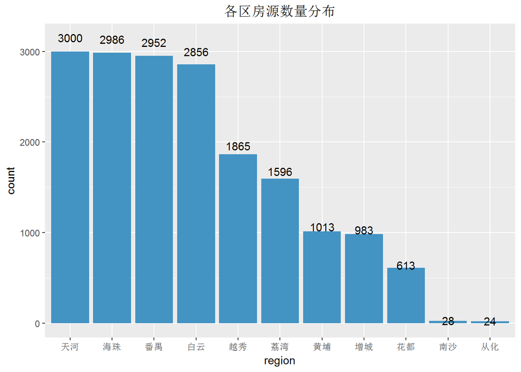

```r
# 先用table()统计出各区房子数量
amount <- data.frame(table(data$region))

ggplot(data = amount, mapping = aes(x = reorder(Var1, -Freq),y = Freq))+
    # 生成标题
    ggtitle('各区房源数量分布') +
    # 生成条形图，每个柱的宽度0.8，填充'#FF9999'的颜色
    geom_bar(stat = 'identity', fill = "#4393C3") +
    # 标题居中
    theme(plot.title = element_text(hjust = 0.5)) +
    # 在条形图上标注数字
    geom_text(aes(label = Freq),position = position_stack(vjust = 1.05)) +
    # 横轴标签'各区'
    xlab('region') +
    # 纵轴标签'数量'
    ylab('count')
```

总体来看，天河区、海珠区、番禺区、白云区二手房市场可谓相当活跃，这4个区的房源数量远远拉开其他区。同是老城区的越秀区和荔湾区却没有那么多是否与GDP高低相关？

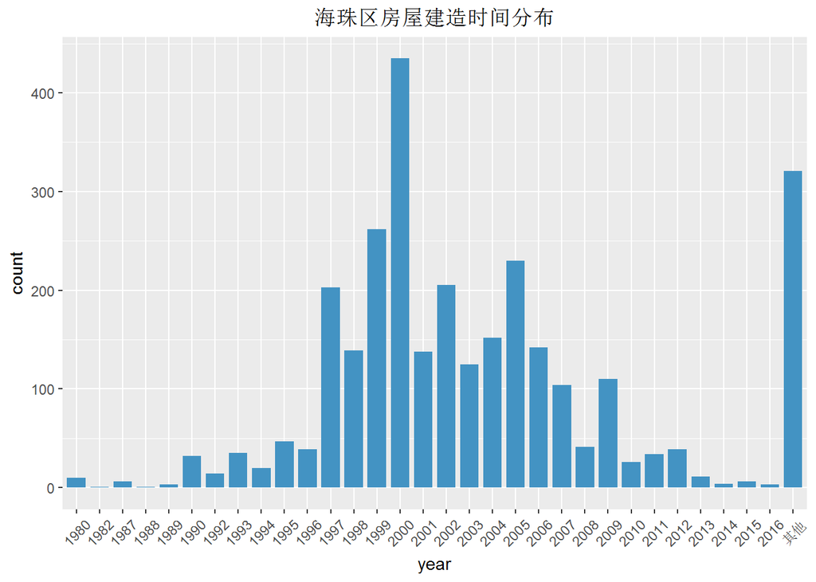

```r
# 海珠区
haizhu = data[6511:9448, ]

ggplot(haizhu, aes(year))+
  geom_bar(stat = 'count', position = 'dodge', width = 0.8, fill = "#4393C3" )+
  ggtitle('海珠区房屋建造时间分布')+
  theme(plot.title = element_text(hjust = 0.5)) + theme(axis.text.x = element_text(angle = 45, hjust = 0.5, vjust = 0.5))
```

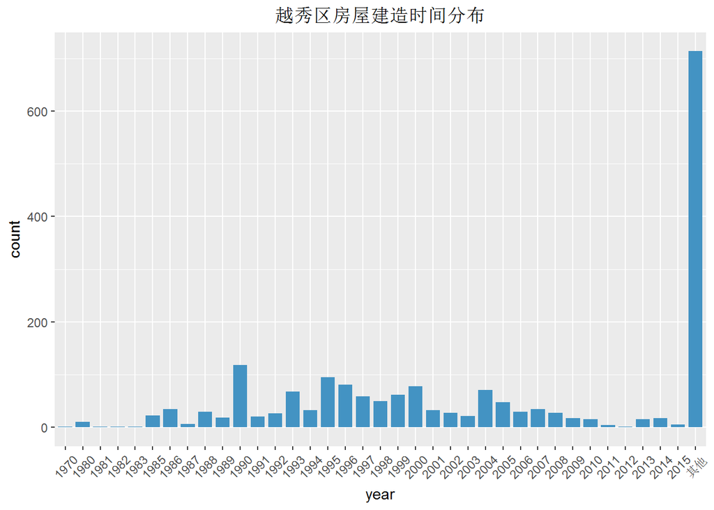

```r
#越秀区
yuexiu = data[3001:4890, ]

ggplot(yuexiu, aes(year)) +
  geom_bar(stat = 'count', position = 'dodge', width = 0.8, fill = "#4393C3")+
  ggtitle('越秀区房屋建造时间分布')+
  theme(plot.title = element_text(hjust = 0.5)) + theme(axis.text.x = element_text(angle = 45, hjust = 0.5, vjust = 0.5))
```

由房屋建造时间分布图可以看到，海珠区在1990-2010年一直发展房地产，吸引了大量人口，房地产市场火爆；对比越秀，越秀需要保护文物古迹，用于可用于商业建房的地方可选择性少，因此建房少。

天河区、海珠区、番禺区、白云区这4个区的房源数量远远拉开其他区。是否与GDP高低相关？下面我们对各区GDP和房源数量做相关性验证。由[广州统计局](http://www.gzstats.gov.cn/)网站公布的数据显示，其各区GDP排名及其值如下：

> GDP排名：天河、黄埔、越秀、番禺、白云、海珠、南沙、花都、荔湾、增城、从化

> GDP值：4317.71, 3209.53, 3193.42, 1948.32, 1782.94,1740.31, 1391.89, 1276.39, 1169.89, 1072.30, 400.44

房源数量：

```r
sort(table(data$region), decreasing = T)
```

```
##
## 天河 海珠 番禺 白云 越秀 荔湾 黄埔 增城 花都 南沙 从化
## 3000 2986 2952 2856 1865 1596 1013  983  613   28   24
```

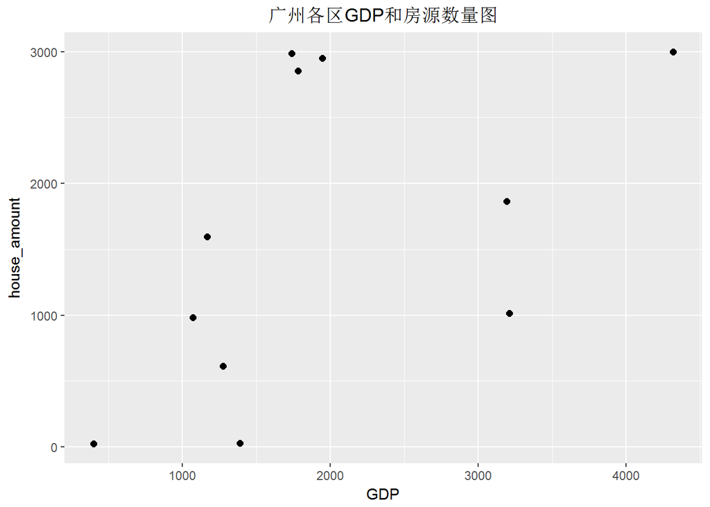

```r
# GDP： 天河、黄埔、越秀、番禺、白云、海珠、南沙、花都、荔湾、增城、从化
 GDP <- c(4317.71, 3209.53, 3193.42, 1948.32, 1782.94, 1740.31, 1391.89, 1276.39, 1169.89, 1072.30, 400.44)
#房源数：天河、黄埔、越秀、番禺、白云、海珠、南沙、花都、荔湾、增城、从化
house_amount <- c(3000, 1013, 1865, 2952, 2856, 2986, 28, 613, 1596, 983, 24)

GDP_house <- data.frame(GDP, house_amount)

ggplot(data = GDP_house, mapping = aes(x = GDP, y = house_amount)) +
    ggtitle('广州各区GDP和房源数量图') +
    # 散点的大小
    geom_point(size = 2) +
    # 背景设置为透明
    theme(plot.title = element_text(hjust = 0.5))
```

由图可知，GDP和房源数量呈正相关的关系。对其进行线性回归拟合：

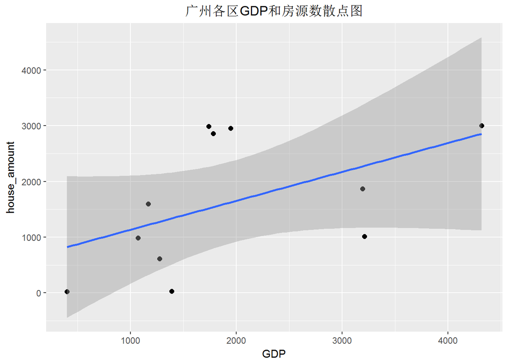

```r
ggplot(data = GDP_house, mapping = aes(x = GDP, y = house_amount)) +
    ggtitle('广州各区GDP和房源数散点图') +
    geom_point(size = 2) +
    theme( plot.title = element_text(hjust = 0.5)) +
    # 线性拟合
    geom_smooth(method = 'lm')
```

阴影区域是线性回归x所对应的y的置信区间域，如果散点都在阴影区域，则说明拟合效果好。从图中可知11个中有5个点是在外面的。说明拟合不好线性相关性强的证据不充分，即相关性比较弱。

因为变量数目少，不能确定其数据分布，所以这里用**Kendall rank correlation test**。计算相关系数 $\rho$ ：

```r
cor.test(x=GDP, y=house_amount, method = "kendall")
```

```
##
##  Kendall's rank correlation tau
##
## data:  GDP and house_amount
## T = 40, p-value = 0.06017
## alternative hypothesis: true tau is not equal to 0
## sample estimates:
##       tau
## 0.4545455
```

相关系数 $\rho$ 为00.4545455，p-value > 0.05，即原假设成立。

**结论**：各区房源与GDP存在弱相关性。

### 二手房户型分布

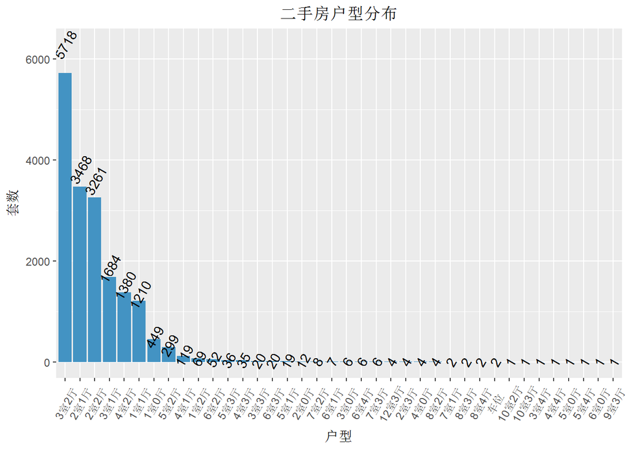

```r
#drops <- c("叠拼别墅", "独栋别墅", "联排别墅", "双拼别墅")
data_type <- data.frame(table(data$roomType))
data_type <- data_type[!grepl("别墅", data_type$Var1), ]
ggplot(data = data_type, mapping = aes(x = reorder(Var1, -Freq), y = Freq)) +
  ggtitle('二手房户型分布') +
  geom_bar(stat = 'identity', fill = "#4393C3") +
  theme(plot.title = element_text(hjust = 0.5), axis.text.x  = element_text(angle = 60, hjust = 0.5, vjust = 0.5)) +
  geom_text(aes(label = Freq), position = position_stack(vjust = 1.1), angle = 60) +
  xlab('户型') +
  ylab('套数')
```

```r
# 观察前10是哪些户型
typetop = sort(summary(data$roomType), decreasing = T)
typetop[1:10]
```

```
## 3室2厅 2室1厅 2室2厅 3室1厅 4室2厅 1室1厅 1室0厅 5室2厅 4室1厅 1室2厅
##   5718   3468   3261   1684   1380   1210    449    299    119     69
```

```r
r3h2 <- data[which(data$roomType=="3室2厅"), ]
summary(r3h2$area)
```

```
##    Min. 1st Qu.  Median    Mean 3rd Qu.    Max.
##    34.0    92.5   102.0   105.5   116.0   287.0
```

```r
summary(r3h2$unitPrice)
```

```
##    Min. 1st Qu.  Median    Mean 3rd Qu.    Max.
##    7500   27460   36212   39076   47283  128713
```

我们发现只有少数几种的户型数量比较多，其余的都非常少，明显属于长尾分布类型（严重偏态）3室2厅户型数量最多，其次是2室1厅。3室2厅平均面积：105.5平方米，平均价格39076元/平方。

### 二手房面积分布

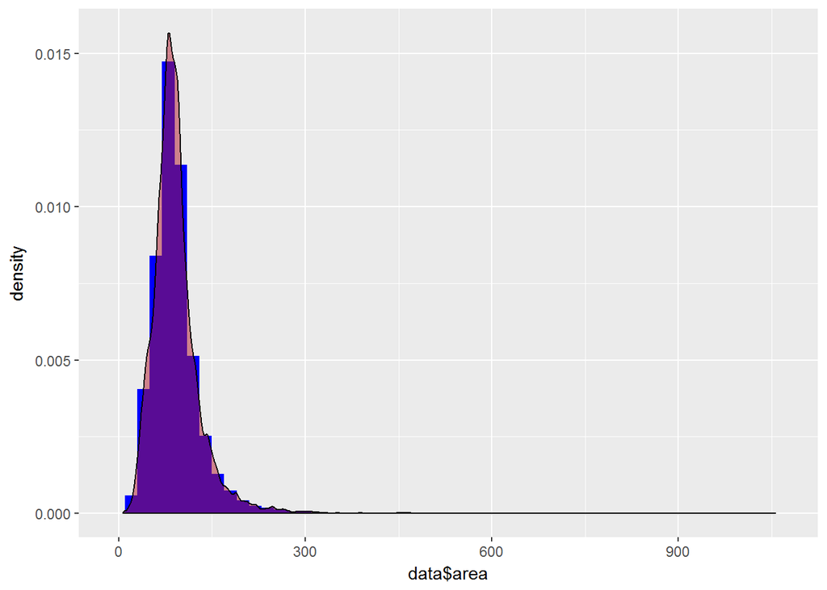

```r
# Histogram overlaid with kernel density curve
ggplot(data, aes(x=data$area)) +
    # 使用density代替y轴
    geom_histogram(aes(y=..density..), binwidth=20, fill="#0000FF") +
    # 重叠部分采用透明设置
    geom_density(alpha=.5, fill= "#B2182B")
```

#### 正态性检验

- Kolmogorov-Smirnov Test（D检验）

这是对经验分布的拟合检验，检验的是经验分布函数和假设总体分布函数的差异，适应于大样本。

```r
# R 语言自带的正态性检测（Kolmogorov-Smirnov 方法）
ks.test(data$area, "pnorm", mean = mean(data$area), sd = sqrt(var(data$area)))
```

```
##
##  One-sample Kolmogorov-Smirnov test
##
## data:  data$area
## D = 0.1151, p-value < 2.2e-16
## alternative hypothesis: two-sided
```

由于p-value < 0.05，所以拒绝原假设，二手房面积分布不符合正态分布。

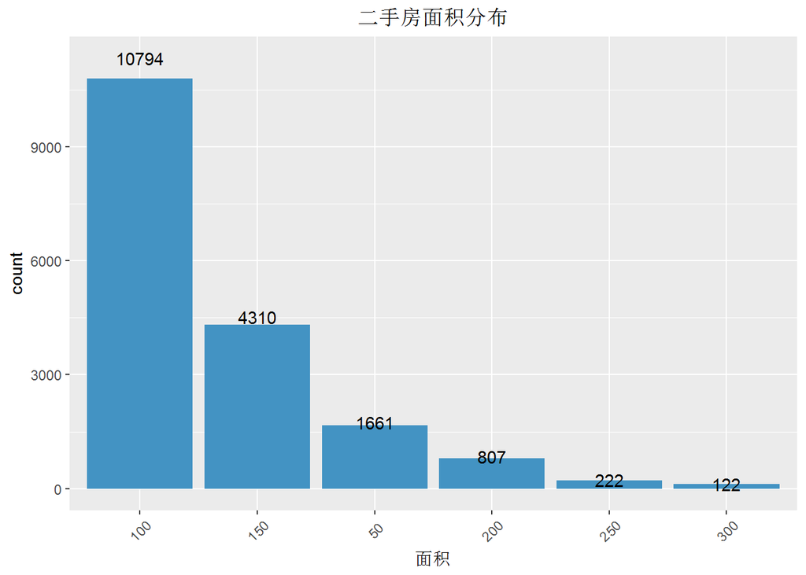

```r
data_area <- data$area

# 把0-50平米的算作50
data_area[data_area < 50] <- 50
# 把50-100平米的算作100
data_area[data_area>50 & data_area<100] <- 100
# 把100-150平米的算作150
data_area[data_area>100 & data_area<150] <- 150
# 把150-200平米的算作200
data_area[data_area>150 & data_area<200] <- 200
# 把200-250平米的算作250
data_area[data_area>200 & data_area<250] <- 250
# 把250平米以上的算作300
data_area[data_area>250] <- 300

data_area <- data.frame(table(data_area))
ggplot(data = data_area, mapping = aes(x = reorder(data_area, -Freq),y = Freq))+
    ggtitle('二手房面积分布')+
    geom_bar(stat = 'identity', fill = "#4393C3") +
    theme(plot.title = element_text(hjust = 0.5), axis.text.x  = element_text(angle = 45, vjust = 0.5)) +
    geom_text(aes(label = Freq),position = position_stack(vjust = 1.05))+
    xlab('面积') +
    ylab('count')
```

```r
# 面积总体情况
summary(data$area)
```

```
##    Min. 1st Qu.  Median    Mean 3rd Qu.    Max.
##    7.76   69.44   86.48   92.06  106.00 1055.98
```

二手房面积总体平均为：92.06平方米。

### 房屋朝向分布

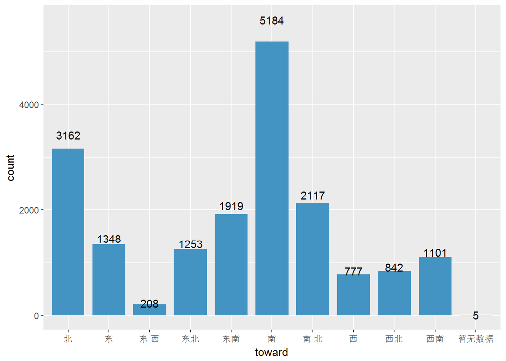

```r
ggplot(data, aes(toward))+
    geom_bar(stat = 'count', position = 'dodge', width = 0.8, fill = "#4393C3")+
    geom_text(stat = "count", aes(label = ..count..), position = position_stack(vjust = 1.08))
```

国人普遍有坐南朝北的思想，所以南、北朝向房屋数量多也就不足为奇了。

### 地址分布

```r
addresstop15 = sort(summary(data$address), decreasing = T)[1:15]
addresstop15
```

```
##    (Other)       市桥       区府       金碧     金沙洲       华南
##        852        805        706        590        540        535
##     凤凰城       新塘 白云大道北       沙湾     新港西       同和
##        504        470        397        389        345        323
##       东圃   天河公园       南浦
##        308        308        298
```

其中，番禺的市桥，黄埔的区府，白云的金碧、金沙洲房源较多。**为什么市桥的房源最多呢？**

- 市桥是番禺区的中心，而番禺区的房源数在广州排第3，所以自然而然是有可能最多的；
- 依托中心城区的区位优势和拥有地铁和密集公路网的优越的交通条件，所以可能更加完善更加宜居。

### 楼层分布

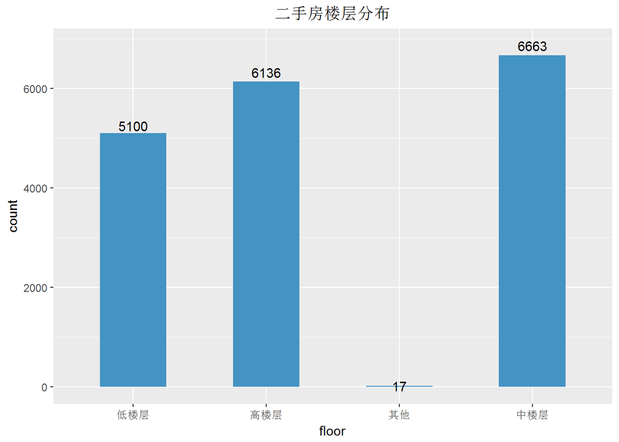

```r
ggplot(data, aes(floor))+
    geom_bar(stat = 'count',position = 'dodge', width = 0.5, fill =  "#4393C3")+
    geom_text(stat = "count",aes(label = ..count..),position = position_stack(vjust = 1.03))+
    ggtitle('二手房楼层分布')+
    theme(plot.title = element_text(hjust = 0.5))
```

中楼层分布较多，中楼层采光好，环境也好，相对高楼层便宜，是大多数人的首选之一。

### 房屋建造时间分布

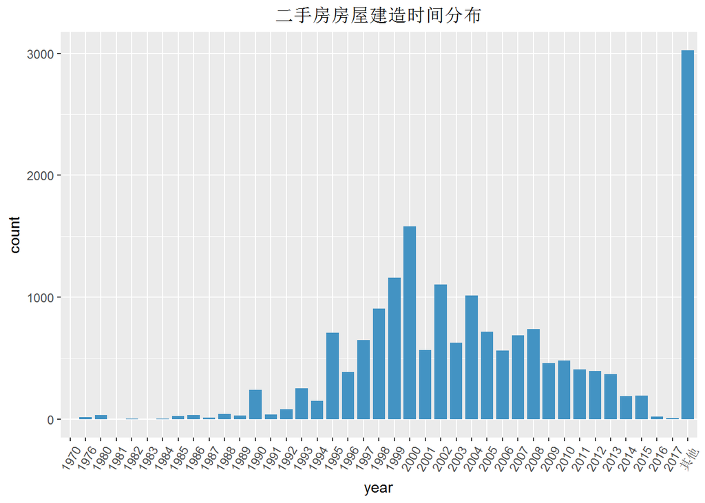

```r
ggplot(data, aes(year))+
  geom_bar(stat = 'count', position = 'dodge', width = 0.8, fill = "#4393C3")+
  ggtitle('二手房房屋建造时间分布') + theme(plot.title = element_text(hjust = 0.5), axis.text.x = element_text(angle = 60, hjust = 0.5, vjust = 0.5), legend.position = "bottom")
```

由图可知，2000年附近有一个建造高峰，另外值得注意的是其他列数量最多，可能原因是房主没有誊写或者已经忘记。

### 总价格分布

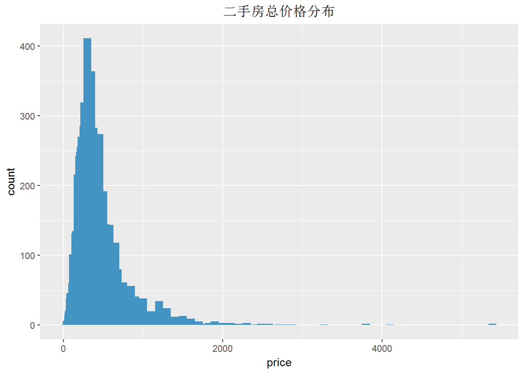

```r
ggplot(data, aes(price))+
    geom_bar(stat = 'count', position = 'dodge', width = 100, fill = "#4393C3")+
    ggtitle('二手房总价格分布')+
    theme(plot.title = element_text(hjust = 0.5))
```

#### 正态性检验

```r
ks.test(data$price, "pnorm", mean = mean(data$area), sd = sqrt(var(data$area)))
```

```
##
##  One-sample Kolmogorov-Smirnov test
##
## data:  data$price
## D = 0.86713, p-value < 2.2e-16
## alternative hypothesis: two-sided
```

由于p-value < 0.05，所以二手房价格分布不符合正态分布。

```r
summary(data$price)
```

```
##    Min. 1st Qu.  Median    Mean 3rd Qu.    Max.
##    30.0   225.0   310.0   370.1   450.0  5388.0
```

其图像是右偏的，说明均值大于中位数，有右偏大奇异点。

```r
sum(data$price > 1000)*1.0/length(data[, 1])
```

```
## [1] 0.02121009
```

```r
# data[data$price > 1000]
data[data$price > 3000, ]
```

|  | houseName | roomType | area | toward | floor | year | address | price | unitPrice | region |
| --- | --- | --- | --- | --- | --- | --- | --- | --- | --- | --- |
| 1370 | 凯旋新世界枫丹丽舍 | 6室2厅 | 468.68 | 东南 | 高楼层 | 2005 | 珠江新城东 | 5388 | 114962 | 天河 |
| 1380 | 金湖雅苑 | 6室4厅 | 1055.98 | 南 北 | 高楼层 | 其他 | 沙太北 | 3270 | 30967 | 天河 |
| 1382 | 凯旋新世界枫丹丽舍 | 6室2厅 | 468.68 | 东南 | 高楼层 | 2005 | 珠江新城东 | 5388 | 114962 | 天河 |
| 14443 | 珠江岭南苑 | 8室2厅 | 387.48 | 南 北 | 低楼层 | 其他 | 黄石路 | 3800 | 98070 | 白云 |
| 14506 | 珠江岭南苑 | 8室2厅 | 387.48 | 南 北 | 低楼层 | 其他 | 黄石路 | 3800 | 98070 | 白云 |
| 15206 | 珠江岭南苑 | 8室2厅 | 388.00 | 南 北 | 中楼层 | 其他 | 黄石路 | 4100 | 105671 | 白云 |

### 单价分布

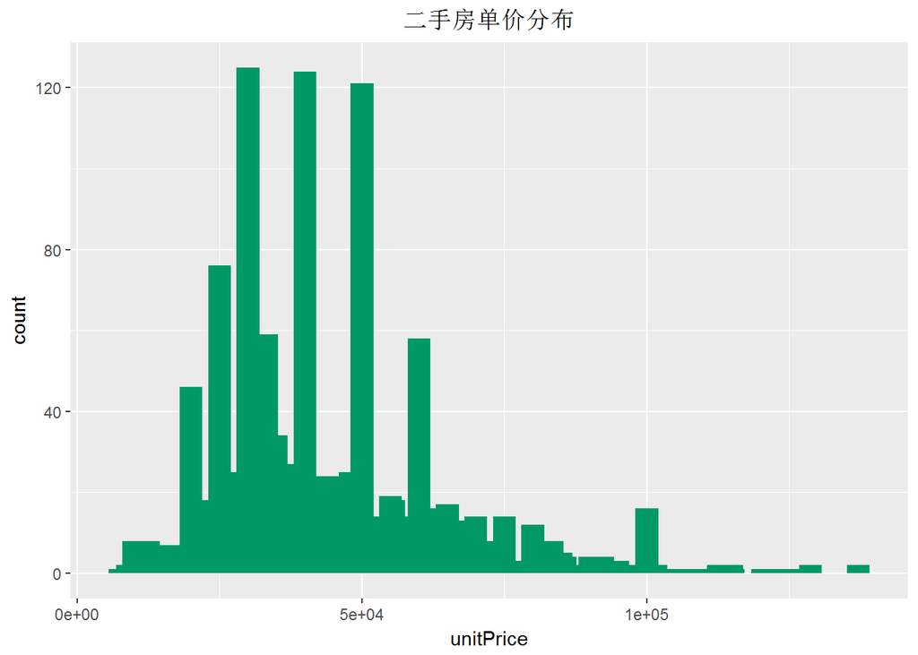

```r
ggplot(data, aes(unitPrice))+
  geom_bar(stat = 'count', position = 'dodge', width = 4000, fill = '#009966')+
  ggtitle('二手房单价分布')+
  theme(plot.title = element_text(hjust = 0.5))
```

```r
summary(data$unitPrice)
```

```
##    Min. 1st Qu.  Median    Mean 3rd Qu.    Max.
##    7500   28768   37405   39916   48111  137105
```

```r
summary(data[data$unitPrice > 100000, ]$region)
```

```
## 白云 从化 番禺 海珠 花都 黄埔 荔湾 南沙 天河 越秀 增城
##    1    0    0    0    0    1    0    0   32   11    0
```

房价超过10w以上的主要分布在天河和越秀。

```r
summary(data[data$unitPrice > 100000, ]$address)
```

[output not shown]

```r
sum(data$unitPrice < 50000)*1.0 / length(data[, 1])
```

```
## [1] 0.7785778
```

77.85778%的房单价处在5w以下。

### 各城区二手房数据概览

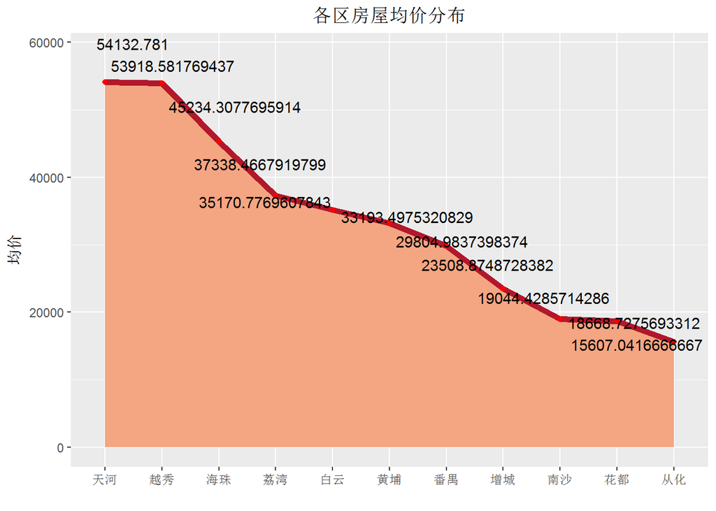

```r
avg_price = aggregate(data$unitPrice,by=list(data$region), mean)

ggplot(avg_price, aes(x = reorder(Group.1, -x), y  = x, group = 1)) +
  geom_area(fill = "#F4A582") + geom_line(color = "#B2182B", size = 2) +
  geom_point() + xlab('') + ylab('均价') + geom_point(color = I("red")) +
  ggtitle('各区房屋均价分布')+
  geom_text_repel(aes(label = x), position = position_stack(vjust = 1.08))+
  theme(plot.title = element_text(hjust = 0.5))
```

很明显，广州二手房价格最高的三个地区为：天河、越秀和海珠，均价都在3.5W以上，价格最低的三个地区为：南沙、花都和从化。

### 各城区二手房总价分布箱线图

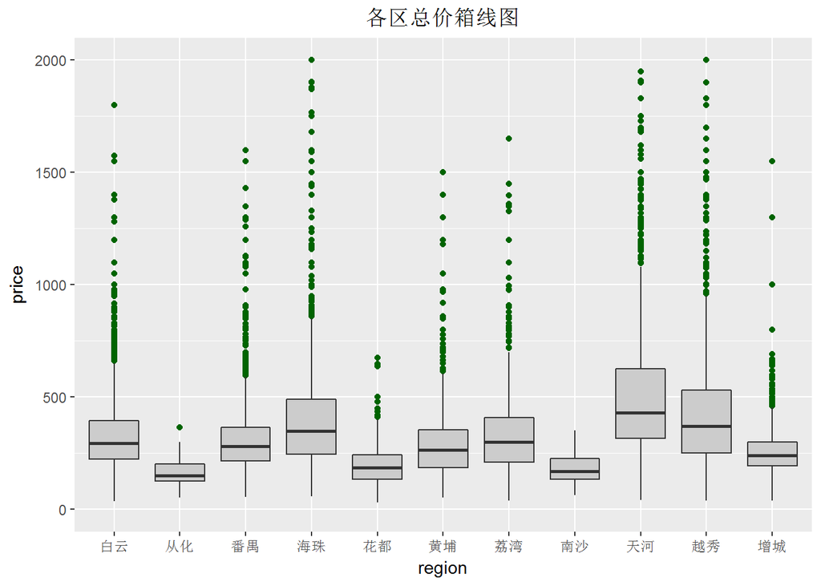

```r
ggplot(data,aes(region,price))+
    geom_boxplot(outlier.color="darkgreen", fill="grey80")+ylim(0, 2000) +
    ggtitle('各区总价箱线图') +
    theme(plot.title = element_text(hjust = 0.5), legend.position = "bottom")
```

各区的中位数都大致在500W以下，500W一套房，首付3成150W，剩下的350W按揭贷款，2018年6月金融机构一年期贷款基准利率下调0.25个百分点至4.35%；30年还款，每月要还17423.41元。

### 各城区二手房单价分布箱线图

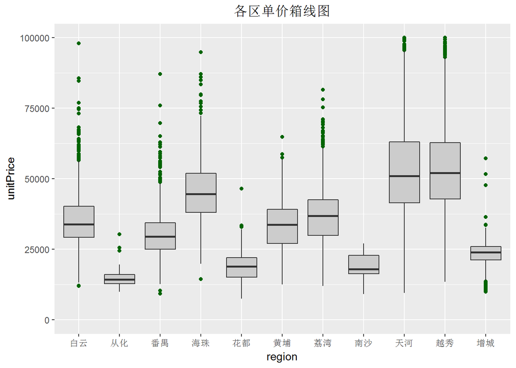

```r
ggplot(data, aes(region,unitPrice))+
    geom_boxplot(outlier.colour="darkgreen", fill="grey80") + ylim(0,100000)+
    ggtitle('各区单价箱线图') +
    theme(plot.title = element_text(hjust = 0.5), legend.position = "bottom")
```

## 二手房数据的简单聚类分析

这么多的房子，我该如何把它们分类呢？即应该把哪些房源归为一类？这就要用到聚类算法了，这里使用简单k-means算法进行聚类分析。根据聚类原则：**组内差距要小，组间差距要大**。我们绘制不同类簇下的组内离差平方和图，聚类过程中，我们选择面积、房价和单价三个数值型变量：

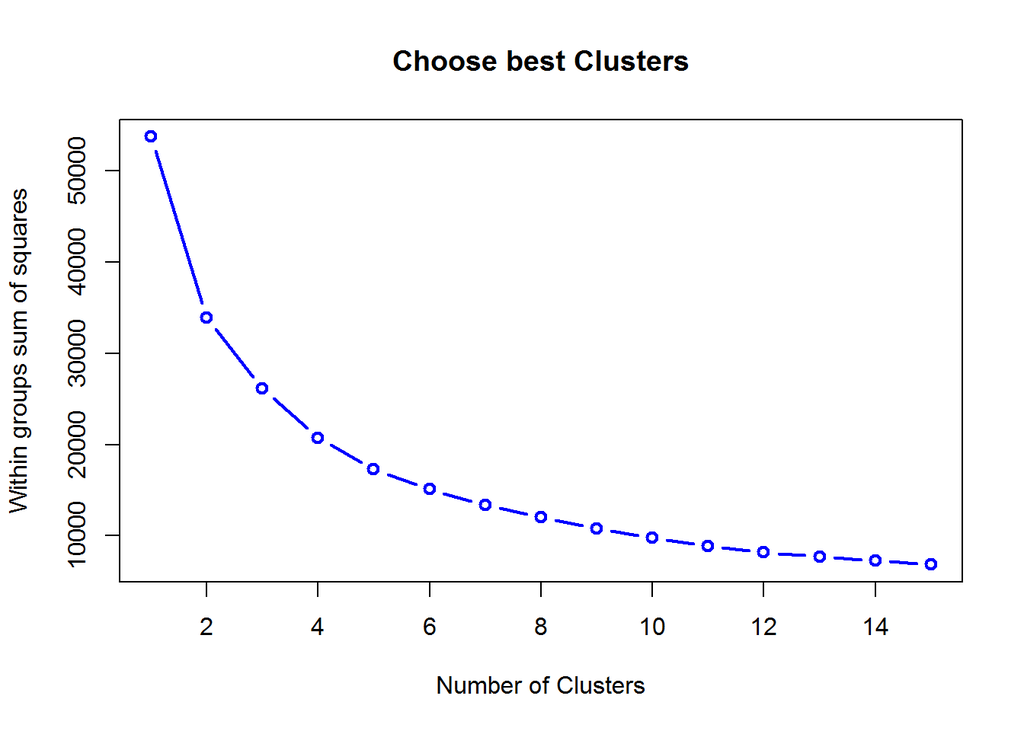

```r
tot.wssplot <- function(data, nc, seed=123) {
  #假设分为一组时的总的离差平方和
  tot.wss <- (nrow(data)-1)*sum(apply(data, 2, var))
  for (i in 2:nc){
    #必须指定随机种子数
    set.seed(seed)
    tot.wss[i] <- kmeans(data, centers=i, iter.max = 100)$tot.withinss
  }
  plot(1:nc, tot.wss, type="b", xlab="Number of Clusters",
       ylab="Within groups sum of squares", col = 'blue',
       lwd = 2, main = 'Choose best Clusters')
}
# 绘制不同聚类数目下的组内离差平方和
standard = data.frame(scale(data[,c('area', 'price', 'unitPrice')]))
myplot <- tot.wssplot(standard, nc = 15)
```

当把所有样本当作一类时，离差平方和达到最大，随着聚类数量的增加，组内离差平方和会逐渐降低，直到极端情况，每一个样本作为一类，此时组内离差平方和为0。从上图看，聚类数量在5次以上，组内离差平方降低非常缓慢，可以把拐点当作5，即可以分成五类。

```r
clust = kmeans(x=standard, centers = 5, iter.max = 100)
table(clust$cluster)
```

```
##
##    1    2    3    4    5
## 2620 2166  369 5641 7120
```

按照聚类的结果，查看各类中的区域分布：

```r
#按照聚类的结果，查看各类中的区域分布：
table(data$region, clust$cluster)
```

```
##
##           1    2    3    4    5
##   白云  496   86   29  717 1528
##   从化    5    0    0    0   19
##   番禺  871   12   35  258 1776
##   海珠  199  506   54 1545  682
##   花都  157    0    0    1  455
##   黄埔  138   14   13  286  562
##   荔湾  231   79   21  539  726
##   南沙    6    0    0    0   22
##   天河  166  970  161 1333  370
##   越秀   69  499   51  961  285
##   增城  282    0    5    1  695
```

各户型的平均面积：

```r
aggregate(data$area, list(data$roomType), mean)
```

| Group.1 | x |
| --- | --- |
| 10室2厅 | 101.68000 |
| 10室3厅 | 456.00000 |
| 12室3厅 | 140.45500 |
| 1室0厅 | 38.51399 |
| 1室1厅 | 46.54197 |
| 1室2厅 | 61.01029 |
| 2室0厅 | 49.73417 |
| 2室1厅 | 67.89321 |
| 2室2厅 | 78.68835 |
| 2室3厅 | 92.79000 |

[output cut: 28 more lines]

按聚类结果，比较各类中房子的平均面积、平均价格和平均单价：

```r
head(data)
```

|  | houseName | roomType | area | toward | floor | year | address | price | unitPrice | region |
| --- | --- | --- | --- | --- | --- | --- | --- | --- | --- | --- |
| 1 | 穗园小区 | 3室2厅 | 96.34 | 东南 | 低楼层 | 2000 | 天润路 | 580 | 60204 | 天河 |
| 2 | 骏景花园 | 3室2厅 | 104.00 | 南 北 | 低楼层 | 2003 | 棠下 | 505 | 48558 | 天河 |
| 3 | 方圆月岛 | 3室2厅 | 132.50 | 南 | 低楼层 | 2009 | 珠江新城中 | 1150 | 86793 | 天河 |
| 4 | 赛拉维 | 2室2厅 | 75.59 | 南 | 低楼层 | 2006 | 员村 | 400 | 52918 | 天河 |
| 5 | 水利电力学院 | 2室2厅 | 67.00 | 南 北 | 高楼层 | 1999 | 天润路 | 339 | 50598 | 天河 |
| 6 | 华景新城翠安侬苑 | 3室2厅 | 109.88 | 南 | 高楼层 | 2002 | 华景新城 | 625 | 56881 | 天河 |

```r
aggregate(data[, c(3, 8, 9)], list(clust$cluster), mean)
```

| Group.1 | area | price | unitPrice |
| --- | --- | --- | --- |
| 1 | 140.65386 | 452.8498 | 32720.29 |
| 2 | 105.31794 | 671.1789 | 65102.10 |
| 3 | 222.88686 | 1439.7851 | 68255.00 |
| 4 | 74.89643 | 345.0375 | 46808.14 |
| 5 | 76.95374 | 212.4081 | 27972.92 |

大体上而言，我们可以将1.8w套广州二手房划分为以下几类：

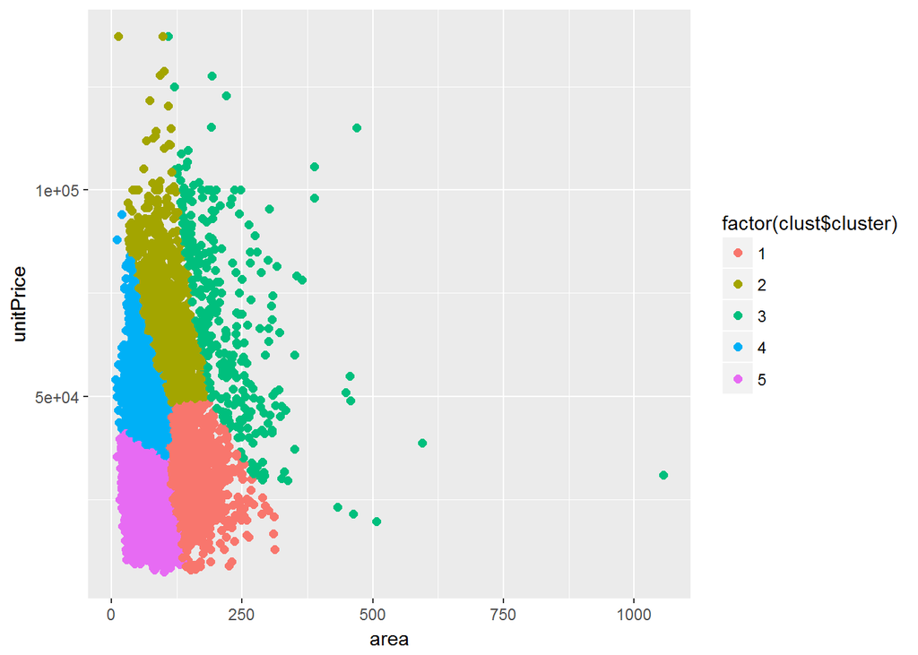

```r
# 绘制面积与单价的散点图，并按聚类进行划分

ggplot(data, mapping = aes(x = area, y = unitPrice, color = factor(clust$cluster))) +
  geom_point(pch = 20, size = 3)
```

接下来借助于已有的数据（房价、面积、单价、楼层、户型、聚类水平）构建线性回归方程，用于房价因素的判断及预测。由于数据中有离散变量，如户型、楼层等，由于其是离散型数据需要对其进行哑变量处理。

```r
library(caret)
# 构造楼层和聚类结果的哑变量
# 将几个离散变量转换为因子，目的便于下面一次性处理哑变量
dataN <- data[, -c(1, 4, 6, 7, 10)]
dataN$cluster <- factor(clust$cluster)

# 筛选出所有因子型变量
factors <- names(dataN)[sapply(dataN, class) == 'factor']

# 将因子型变量转换成公式formula的右半边形式
formula <- as.formula(paste('~', paste(factors, collapse = '+')))
dummy <- dummyVars(formula = formula, data = dataN)
pred <- predict(dummy, newdata = dataN)
head(pred)
```

```
##   roomType.10室2厅 roomType.10室3厅 roomType.12室3厅 roomType.1室0厅
## 1                0                0                0               0
## 2                0                0                0               0
## 3                0                0                0               0
## 4                0                0                0               0
## 5                0                0                0               0
## 6                0                0                0               0
##   roomType.1室1厅 roomType.1室2厅 roomType.2室0厅 roomType.2室1厅
## 1               0               0               0               0
## 2               0               0               0               0
## 3               0               0               0               0
## 4               0               0               0               0
## 5               0               0               0               0
## 6               0               0               0               0
##   roomType.2室2厅 roomType.2室3厅 roomType.3室0厅 roomType.3室1厅
```

[output cut: 69 more lines]

```r
# 将哑变量规整到dataN数据集中
final_house <- cbind(dataN, pred)

# 筛选出需要建模的数据
model.data <- subset(final_house, select = c(2, 4, 5, 10, 11, 14, 15, 18, 19, 24, 29, 49, 50, 52, 53, 54, 55, 56))

# 直接对数据进行线性回归建模
fit <- lm(price ~ ., data = model.data)

summary(fit)
```

```
##
## Call:
## lm(formula = price ~ ., data = model.data)
##
## Residuals:
##      Min       1Q   Median       3Q      Max
## -1111.98   -18.48     4.56    21.08  2506.80
##
## Coefficients:
##                   Estimate Std. Error t value Pr(>|t|)
## (Intercept)     -4.367e+02  1.655e+01 -26.394  < 2e-16 ***
## area             3.983e+00  2.604e-02 152.963  < 2e-16 ***
## unitPrice        9.980e-03  6.239e-05 159.948  < 2e-16 ***
## roomType.1室0厅 -4.593e+00  4.948e+00  -0.928 0.353323
## roomType.1室1厅  2.387e+00  4.202e+00   0.568 0.570024
## roomType.2室1厅  7.127e+00  3.699e+00   1.927 0.054056 .
## roomType.2室2厅  8.555e+00  3.627e+00   2.359 0.018357 *
## roomType.3室1厅  1.306e+01  3.712e+00   3.518 0.000435 ***
## roomType.3室2厅  1.496e+01  3.378e+00   4.428 9.58e-06 ***
## roomType.4室2厅  9.140e+00  3.619e+00   2.526 0.011554 *
## roomType.5室2厅 -1.892e+01  4.964e+00  -3.811 0.000139 ***
## floor.低楼层     5.566e+01  1.605e+01   3.468 0.000525 ***
## floor.高楼层     5.277e+01  1.604e+01   3.291 0.001002 **
## floor.中楼层     5.421e+01  1.604e+01   3.379 0.000730 ***
## cluster.1       -6.093e+01  2.165e+00 -28.149  < 2e-16 ***
## cluster.2       -2.625e+01  3.055e+00  -8.594  < 2e-16 ***
## cluster.3        2.513e+02  5.925e+00  42.407  < 2e-16 ***
## cluster.4       -4.677e+01  1.651e+00 -28.327  < 2e-16 ***
## ---
## Signif. codes:  0 '***' 0.001 '**' 0.01 '*' 0.05 '.' 0.1 ' ' 1
##
## Residual standard error: 65.84 on 17898 degrees of freedom
## Multiple R-squared:  0.9296, Adjusted R-squared:  0.9295
## F-statistic: 1.39e+04 on 17 and 17898 DF,  p-value: < 2.2e-16
```

```r
# Cox-Box转换
library(car)
powerTransform(fit)
```

```
## Estimated transformation parameter
##        Y1
## 0.3951325
```

根据结果显示，0.3951325非常接近0.5，查表将二手房的价格进行开方变换。

```r
fit1 <- lm(sqrt(price) ~ .,data = model.data)

summary(fit1)
```

```
##
## Call:
## lm(formula = sqrt(price) ~ ., data = model.data)
##
## Residuals:
##     Min      1Q  Median      3Q     Max
## -38.915  -0.302   0.151   0.508   6.198
##
## Coefficients:
##                   Estimate Std. Error t value Pr(>|t|)
## (Intercept)      8.905e-01  2.619e-01   3.401 0.000673 ***
## area             8.108e-02  4.120e-04 196.781  < 2e-16 ***
## unitPrice        2.229e-04  9.874e-07 225.786  < 2e-16 ***
## roomType.1室0厅 -1.881e+00  7.830e-02 -24.020  < 2e-16 ***
## roomType.1室1厅 -1.140e+00  6.650e-02 -17.137  < 2e-16 ***
## roomType.2室1厅  1.310e-01  5.854e-02   2.237 0.025273 *
## roomType.2室2厅  4.754e-01  5.741e-02   8.281  < 2e-16 ***
## roomType.3室1厅  7.904e-01  5.874e-02  13.457  < 2e-16 ***
## roomType.3室2厅  9.124e-01  5.345e-02  17.069  < 2e-16 ***
## roomType.4室2厅  7.686e-01  5.727e-02  13.420  < 2e-16 ***
## roomType.5室2厅  3.751e-01  7.855e-02   4.775 1.81e-06 ***
## floor.低楼层     7.149e-01  2.540e-01   2.815 0.004886 **
## floor.高楼层     6.429e-01  2.538e-01   2.533 0.011322 *
## floor.中楼层     7.086e-01  2.539e-01   2.791 0.005259 **
## cluster.1        2.057e-02  3.426e-02   0.600 0.548294
## cluster.2        4.722e-01  4.834e-02   9.768  < 2e-16 ***
## cluster.3        2.040e+00  9.376e-02  21.753  < 2e-16 ***
## cluster.4        3.579e-02  2.613e-02   1.370 0.170831
## ---
## Signif. codes:  0 '***' 0.001 '**' 0.01 '*' 0.05 '.' 0.1 ' ' 1
##
## Residual standard error: 1.042 on 17898 degrees of freedom
## Multiple R-squared:  0.9624, Adjusted R-squared:  0.9623
## F-statistic: 2.692e+04 on 17 and 17898 DF,  p-value: < 2.2e-16
```

## 总结

最后我们再看一下，关于最终模型的诊断结果：

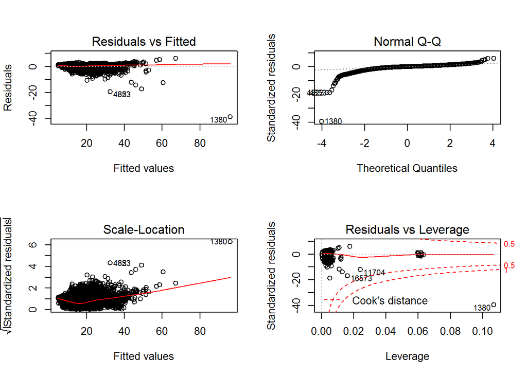

```r
# 使用plot方法完成模型定性的诊断
opar <- par(no.readonly = TRUE)

par(mfrow = c(2,2))

plot(fit1)
```

```r
par(opar)
```

*参考文献*

- *[广州二手房市场数据分析](https://zhuanlan.zhihu.com/p/34639593)*